# Lista 4 - Geração de variáveis aleatórias uniformes

#### 1. Como seria um método simples para avaliar se uma sequência de números aleatórios segue uma distribuição uniforme? Implementar sua ideia.

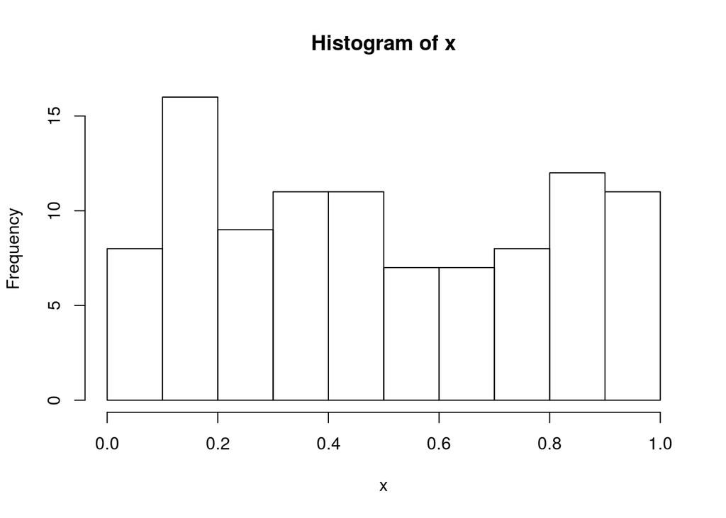

```
## $prob
##  [1] 0.08 0.16 0.09 0.11 0.11 0.07 0.07 0.08 0.12 0.11
##
## $dif
##  [1] -0.02  0.06 -0.01  0.01  0.01 -0.03 -0.03 -0.02  0.02  0.01
##
## $mean.dif
## [1] "Mean relative difference: 0.22"
```

```r
gna0 <- function(n, sem=0){
  gnu0 <- function(sem){  # função local
    k <- sem %/% iq # divisão de inteiros
    # calculando (ia * sem mod im) sem provocar overflow- Schrage
    sem = ia * (sem %% iq) - ir * k
    if (sem < 0) sem <- sem+im
    ran0 <- am * sem # converte sem para ponto flutuante
    return(list(ran0 = ran0, sem = sem))
  }
  ia <- 16807; im <- 2147483647; am <- 1.0/im
  iq <- 127773; ir <- 2836
  if (sem <= 0){
    t <- as.numeric(substring(Sys.time(),
                              c(1,6,9,12,15,18),c(4,7,10,13,16,19))) #relógio/sist.
    sem <- t[6]+t[5]*60+t[4]*3600
    sem <- ia * (sem %% iq) - ir * (sem %/% iq)# retirar o efeito inicial
    if (sem <= 0) sem <- sem + im
  }
  u <- matrix(0, n, 1) # inicia o vetor de resultados
  amostra <- gnu0(sem) #chama gnu0
  u[1] <- amostra$ran0 # inicia o primeiro elemento
  for (i in 2:n){
    amostra <- gnu0(amostra$sem)
    u[i] <- amostra$ran0
  }
  return(u)
}

n = 100
testa_gerador = function(x){
  l = length(x)
  tab = table(cut(x, seq(0,1, by = 0.1))) / l
  v = as.vector(tab)
  r1 = all.equal(v, rep(0.1,10))
  r2 = v - rep(0.1,10)
  hist(x)
  list(prob=v, dif=r2, mean.dif=r1)
}

n = 100
set.seed(2)
x = runif(n)
testa_gerador(x)
```

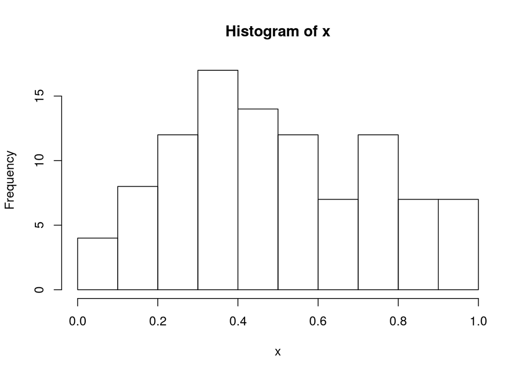

```
## $prob
##  [1] 0.04 0.08 0.12 0.17 0.14 0.12 0.07 0.12 0.07 0.07
##
## $dif
##  [1] -0.06 -0.02  0.02  0.07  0.04  0.02 -0.03  0.02 -0.03 -0.03
##
## $mean.dif
## [1] "Mean relative difference: 0.34"
```

```r
testa_gerador(gna0(n))
```

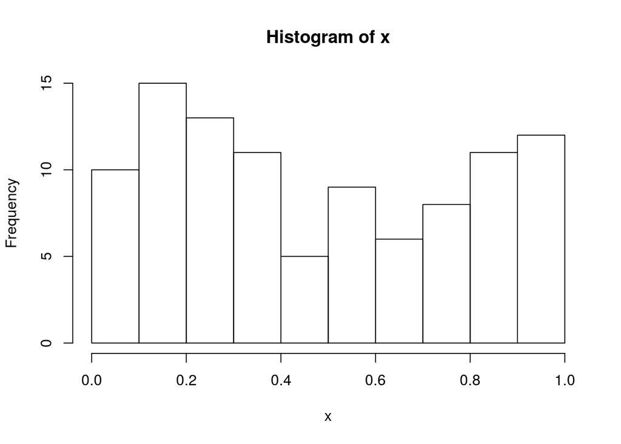

```
## $prob
##  [1] 0.10 0.15 0.13 0.11 0.05 0.09 0.06 0.08 0.11 0.12
##
## $dif
##  [1]  0.00  0.05  0.03  0.01 -0.05 -0.01 -0.04 -0.02  0.01  0.02
##
## $mean.dif
## [1] "Mean relative difference: 0.2666667"
```

```r
testa_gerador(runif(n))
```

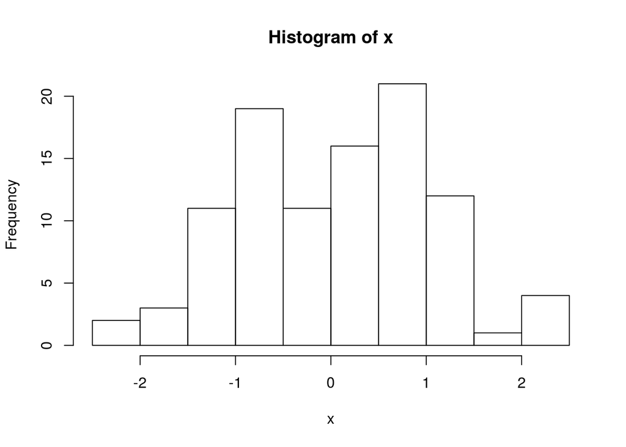

```
## $prob
##  [1] 0.03 0.02 0.02 0.05 0.04 0.06 0.04 0.05 0.03 0.03
##
## $dif
##  [1] -0.07 -0.08 -0.08 -0.05 -0.06 -0.04 -0.06 -0.05 -0.07 -0.07
##
## $mean.dif
## [1] "Mean relative difference: 1.702703"
```

```r
testa_gerador(rnorm(n))
```

#### 2. Utilizar o gerador `gna01` para gerar $n$ realizações de uma distribuição exponencial $f(x) = \lambda e^ {−\lambda x}$. Sabemos do teorema da transformação de probabilidades:

- Se $U$ tem distribuição uniforme, $R X = F^{−1} (U)$ tem distribuição de probabilidade com densidade $f(x) = F'(x)$; em que $F(x) = \int_{-\infty}^{x} f (t)dt$ é a função de distribuição de $X$ e $F^{−1} (y)$ é a sua função inversa para o valor $y$.
- Para a exponencial, a função de distribuição de probabilidade é $F(x) = \int_{0}^{x} \lambda e ^{−\lambda t} dt$ = 1 − e −λx
- Devido à simetria da distribuição uniforme, $1 − u$ pode ser trocado por $u$. O resultado final é: $x = − ln(u)/\lambda$.

**a) Fazer isso para construir uma função chamada `gexp` que recebe os parâmetros $n$ e $\lambda$, usa a função `gna0` para gerar amostras uniformes e retorna $n$ realizações exponenciais.**

```r
gexp = function(n,l){
  x = (-log(gna0(n)))/l
  return(x)
}
```

```r
n = 10000
l = 3
a = gexp(n,l)
head(a)
```

```
##            [,1]
## [1,] 0.16286583
## [2,] 0.04915267
## [3,] 0.10121624
## [4,] 0.17900230
## [5,] 0.16530542
## [6,] 0.13080531
```

**c) Obter o histograma da amostra simulada.**

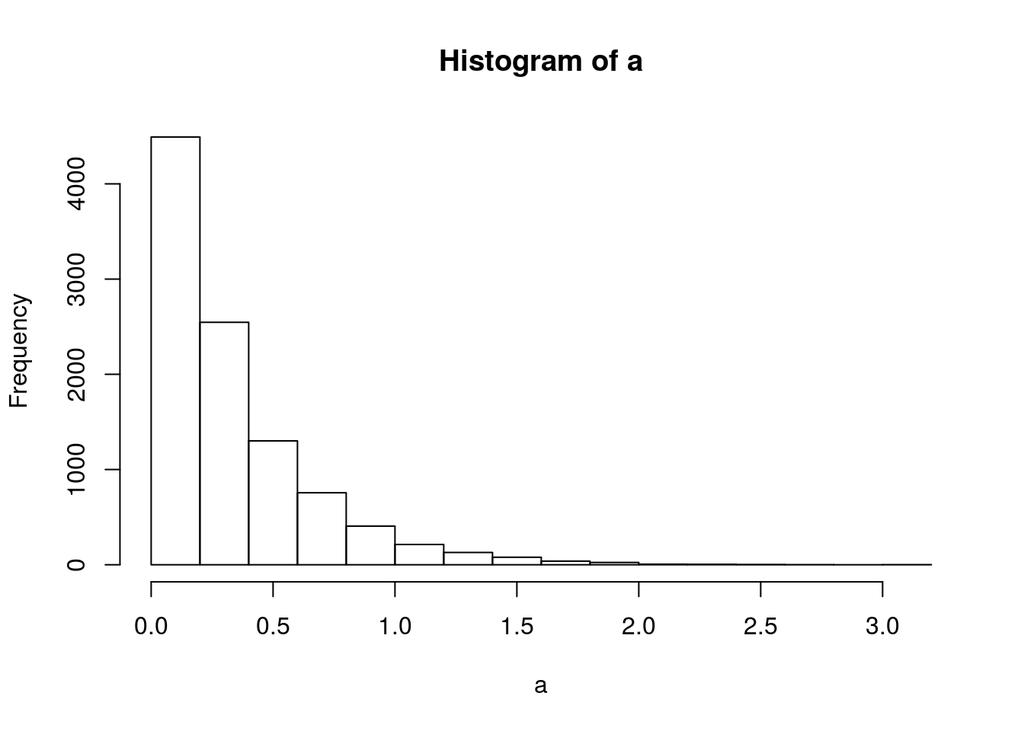

```r
hist(a)
```

**d) Calcule a média, a variância e o desvio padrão e confronte com os valores teóricos da distribuição exponencial.**

```r
mean(a)
```

```
## [1] 0.3329113
```

```r
l**(-1)
```

```
## [1] 0.3333333
```

```r
var(a)
```

```
##          [,1]
## [1,] 0.110014
```

```r
l**(-2)
```

```
## [1] 0.1111111
```

```r
sd(a)
```

```
## [1] 0.3316836
```

```r
sqrt(l**(-2))
```

```
## [1] 0.3333333
```